# Activity Monitoring Data

## Introduction

It is now possible to collect a large amount of data about personal movement using activity monitoring devices such as a Fitbit, Nike Fuelband, or Jawbone Up. These type of devices are part of the “quantified self” movement – a group of enthusiasts who take measurements about themselves regularly to improve their health, to find patterns in their behavior, or because they are tech geeks. But these data remain under-utilized both because the raw data are hard to obtain and there is a lack of statistical methods and software for processing and interpreting the data.

This report makes use of data from a personal activity monitoring device. This device collects data at 5 minute intervals through out the day. The data consists of two months of data from an anonymous individual collected during the months of October and November, 2012 and include the number of steps taken in 5 minute intervals each day.

First lets read in the data and store in variable called activity.

```r
activity <- read.csv("data/activity.csv", stringsAsFactors = FALSE)
```

To clean up the data we will convert steps to a numeric and Dates to the date datatype.

```r
activity_na_rm <- activity[!is.na(activity$steps),]
activity_na_rm$steps <- as.numeric(activity_na_rm$steps)
activity_na_rm$date <- as.Date(activity_na_rm$date, "%Y-%m-%d")
```

Lets calculate the mean total number of steps taken per day. But first lets visualize the data in a histogram of the total number of steps taken each day.

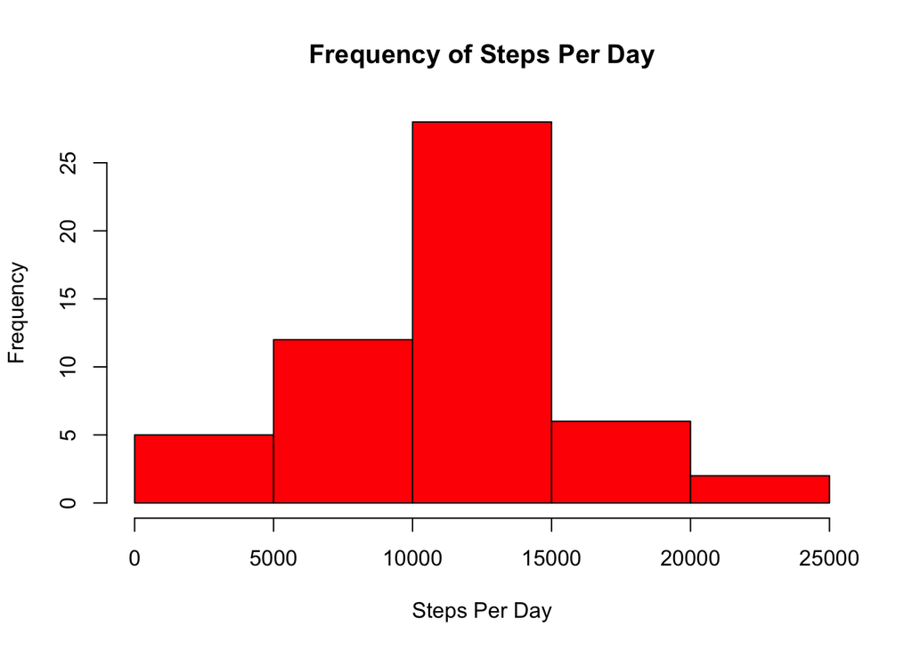

```r
activity_sums <- aggregate(steps ~ date, activity_na_rm, sum)
hist(activity_sums$steps, breaks = 5, main = "Frequency of Steps Per Day", xlab = "Steps Per Day", ylab = "Frequency", col = "red")
```

Now lets calculate the mean and median number of steps taken each day Mean:

```r
round(mean(activity_sums$steps))
```

```
## [1] 10766
```

Median:

```r
round(median(activity_sums$steps))
```

```
## [1] 10765
```

Now that we know a little bit more about the average step count lets try and figure out at what time the subjects walk the most.

To do this we will visualize the average daily activity pattern by generating a time series plot of the average number of steps taken.

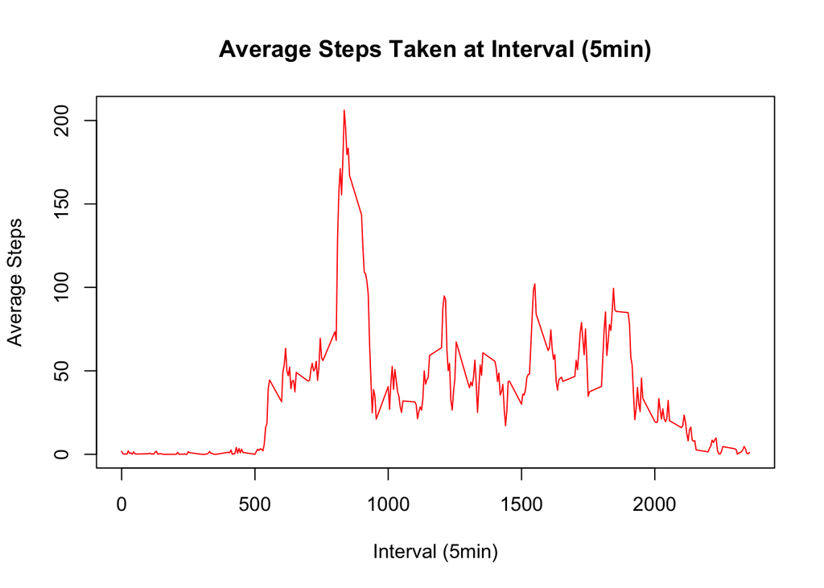

```r
meansteps_per_interval <- tapply(X = activity_na_rm$steps, INDEX = activity_na_rm$interval, FUN = mean)
plot(x = unique(activity_na_rm$interval), y = meansteps_per_interval, type = "l", main = "Average Steps Taken at Interval (5min)", xlab = "Interval (5min)", ylab = "Average Steps", col = "red")
```

From the time series plot we can see that the average maximum number of steps occur between interval 500 and 1000, but its hard to tell the exact interval. Lets calculate the exact interval.

```r
meansteps_per_interval <- data.frame(interval = names(meansteps_per_interval), avg_steps = meansteps_per_interval, stringsAsFactors = FALSE)
max_interval <- max(meansteps_per_interval$avg_steps)
max_steps_interval <- meansteps_per_interval[meansteps_per_interval$avg_steps == max_interval,]$interval
max_steps_interval
```

```
## [1] "835"
```

We now know that on average the most steps occur during the interval 835.

**Note**: There are a number of days/intervals where there are missing values (coded as 𝙽𝙰). The presence of missing days may introduce bias into some calculations or summaries of the data.

Lets calculate the total number of missing values.

```r
missing_values <- nrow(activity[is.na(activity$steps),])
```

We have 2304 NA’s.

To generate a more acurate graph lets replace the NA step counts with the average count for that interval. Then plot on a histogram.

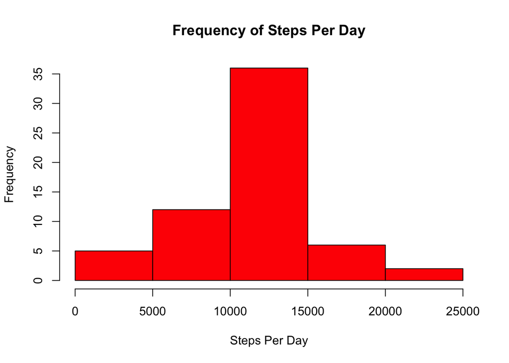

```r
for(i in 1:nrow(activity)) {
  if(is.na(activity$steps[i])) {
    curr_steps <- meansteps_per_interval$avg_steps[which(meansteps_per_interval$interval == activity$interval[i])]
    activity$steps[i] <- curr_steps
  }
}

activity_sums_no_nas <- aggregate(steps ~ date, activity, sum)

hist(activity_sums_no_nas$steps, breaks = 5, main = "Frequency of Steps Per Day", xlab = "Steps Per Day", ylab = "Frequency", col = "red")
```

Now lets calculate the mean and median number of steps taken each day with the missing data filled in. Mean:

```r
round(mean(activity_sums_no_nas$steps))
```

```
## [1] 10766
```

Median:

```r
round(median(activity_sums_no_nas$steps))
```

```
## [1] 10766
```

We can see not much has change in the form of mean and median from when we just removed the NA’s.

Now we will look at the trends of steps between weekend and weekday. To do this we will split the data between two factors “weekend” and “weekday”.

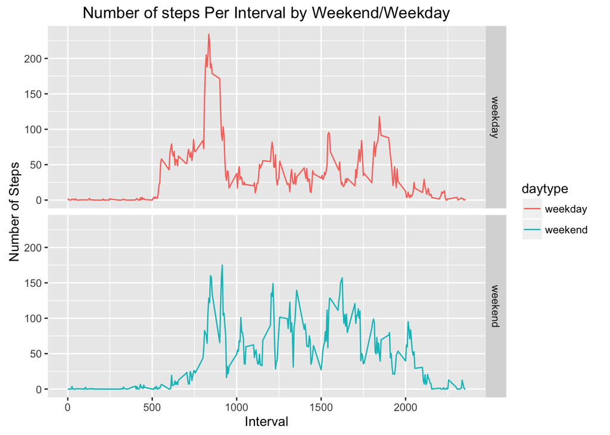

```r
library(ggplot2)
weekday <- function(aDate) {
    wd <- weekdays(aDate)
    if  (wd == 'Saturday' || wd == 'Sunday') {
        x <- 'weekend'
    } else {
        x <- 'weekday'
    }
    x
}

activity_na_rm$daytype <- as.factor(sapply(activity_na_rm$date, weekday))

activity_na_rm <- aggregate(steps ~ interval+daytype, activity_na_rm, mean)

plt <- ggplot(activity_na_rm, aes(interval, steps)) + geom_line(stat = "identity", aes(colour = daytype)) +
    facet_grid(daytype ~ ., scales="fixed", space="fixed") + xlab("Interval") +
    ylab("Number of Steps") + ggtitle("Number of steps Per Interval by Weekend/Weekday")

print(plt)
```